# NHANES 2013–2014 cycle Project Report

Noghre Najafi *Supervised by Dr. Mark Ghamsary, Professor (Retired), UCLA

2025-09-12

# 1 **Introduction**

## 1.1 **Data Source**

Data were obtained from the **NHANES 2013–2014 cycle**, a nationally representative cross-sectional survey of the U.S. population. This cycle includes about **10,000** participants with demographic, laboratory, physical examination, and questionnaire data.

## 1.2 **Variables**

- Outcome: hsCRP (high-sensitivity C-reactive protein).
- Clinical/lab: SBP, DBP, Cholesterol, LDL, HDL, Triglycerides, Glucose, CBC indices (WBC, HGB, RBC, MCV, MCH, MCHC, RDW, MPV, PLT), BMI.
- Trace elements: Copper, Zinc (subsample, ~2,500–3,000 participants).
- Derived variables: LdlHdl (LDL/HDL), Zinc_Copper (Zinc/Copper ratio).
- Health history: CVD (0 , 1), Diabetes, HTN, HistoryCVD, HistoryDiabetes.
- Psychosocial/lifestyle: Depression score (PHQ-9), Physical Activity (PAL), Age, Sex (male = 0, female = 1).

## 1.3 **Notes**

- The analysis included: hsCRP (outcome), HDL, DBP, Cholesterol, BMI, Age, Sex, CVD and Physical Activity (PAL) as predictors.
- NHANES data are collected using standardized protocols and quality-controlled laboratories.
- Sample sizes vary by variable due to subsampling (e.g., trace elements) and missing data.

# 2 **Project Goal**

The primary goal of this project is to implement and evaluate three distinct regression models—**Linear Regression, Binary Logistic Regression**, and **Ordinal Regression**—to predict **hsCRP** using data from the **National Health and Nutrition Examination Survey (NHANES) 2013-2014** cycle.

This nationally representative dataset provides a robust foundation for comparing model performance on a real-world, public health problem. The analysis will determine which modeling technique best captures the relationships within the data and most accurately predicts the outcome. The chosen model could serve as a valuable tool for identifying key factors associated with **hsCRP**.

## 2.1 **Key steps will include:**

1. Preprocessing the “NHANES” data (handling missing values, encoding categorical variables).
2. Implementing the three regression techniques.
3. Evaluating and comparing model performance using appropriate metrics.
4. Identifying the model with the best fit and highest predictive accuracy for this specific task.

# 3 **Data Cleaning**

## 3.1 **missing data**

First, we look for missing data to find out how many there are:

```
##       hsCRP         PAL         Age         Sex         DBP Cholesterol
##         960         918         897         891         925         956
##         BMI         CVD         HDL
##         910         891         956
```

About 10% of the data is missing, which is a significant amount.

### 3.1.1 **Multiple imputation with MCMC**

We **impute** the missing values using the **MCMC method** in the `mice` package. Convergence is checked by plotting the mean and standard deviation of imputations across iterations. The stable trace plots confirm that the chains have converged.

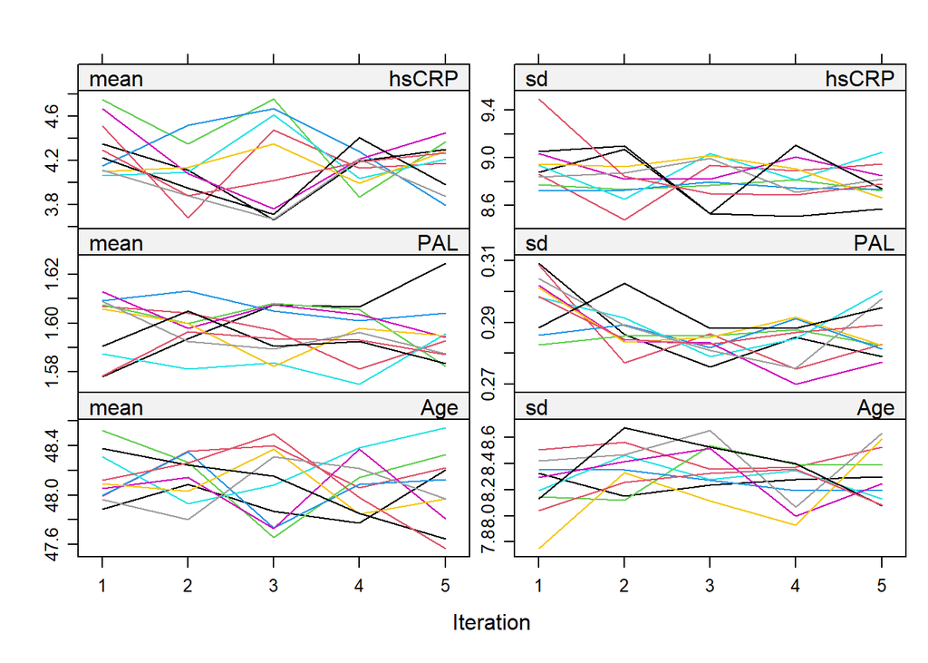

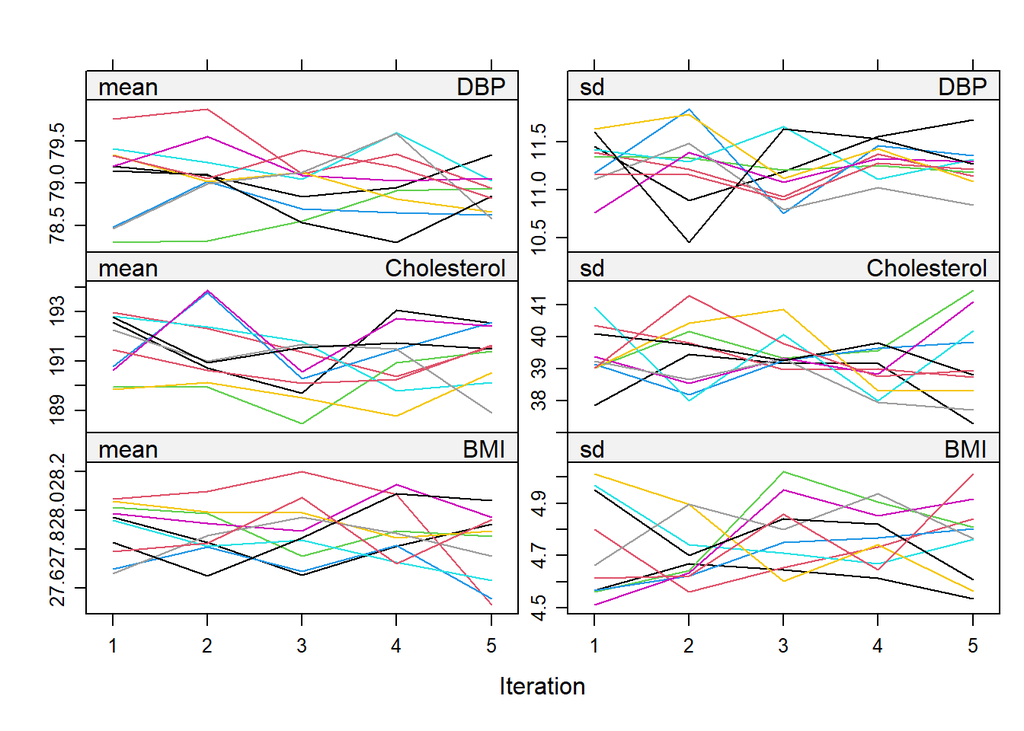

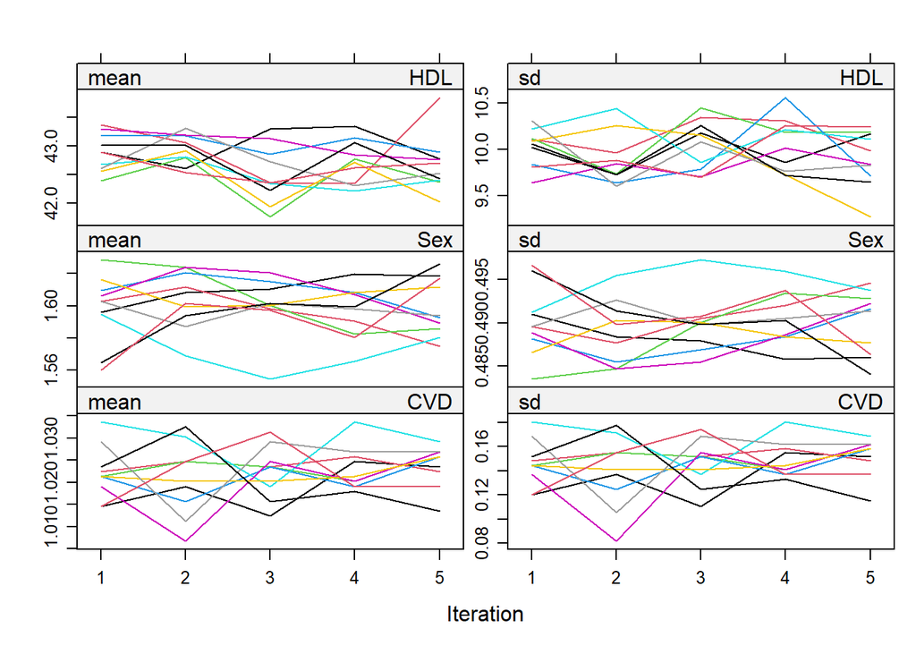

On the left side, the mean of imputed values is shown across iterations for each dataset (colored lines). The lines remain relatively flat and stable, indicating that the mean values have converged. On the right side, the standard deviation of imputed values is shown. Again, the lines are stable across iterations, confirming that the variability of imputations has also converged. Together, **these plots demonstrate that the MCMC imputation process reached convergence with no major fluctuations**.

### 3.1.2 **Distribution of imputed values**

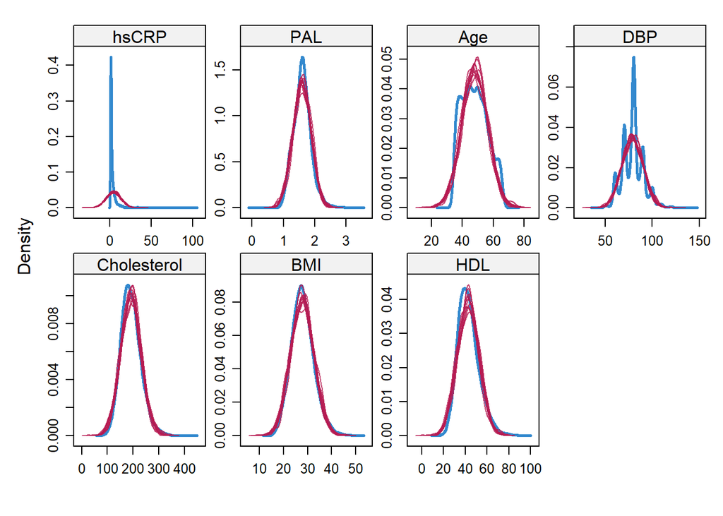

Similar distributions indicate stability and convergence, and we can see more stability and convergence in **PAL, Age, DBP, BMI, HDL, Cholesterol** than in **hsCRP** .

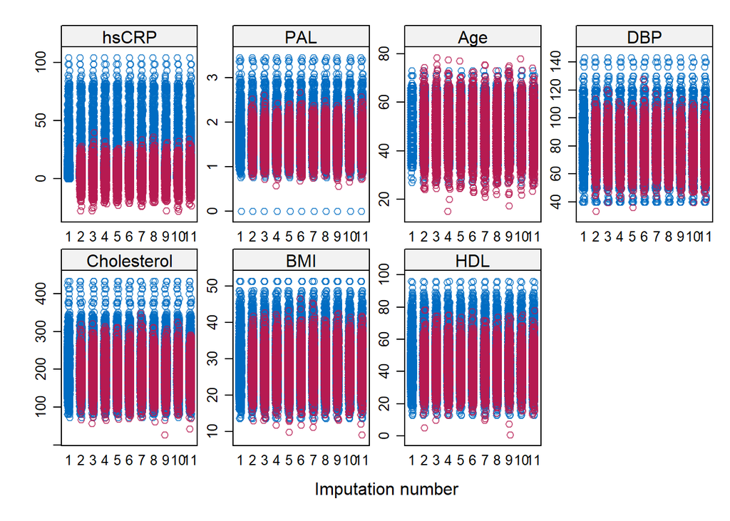

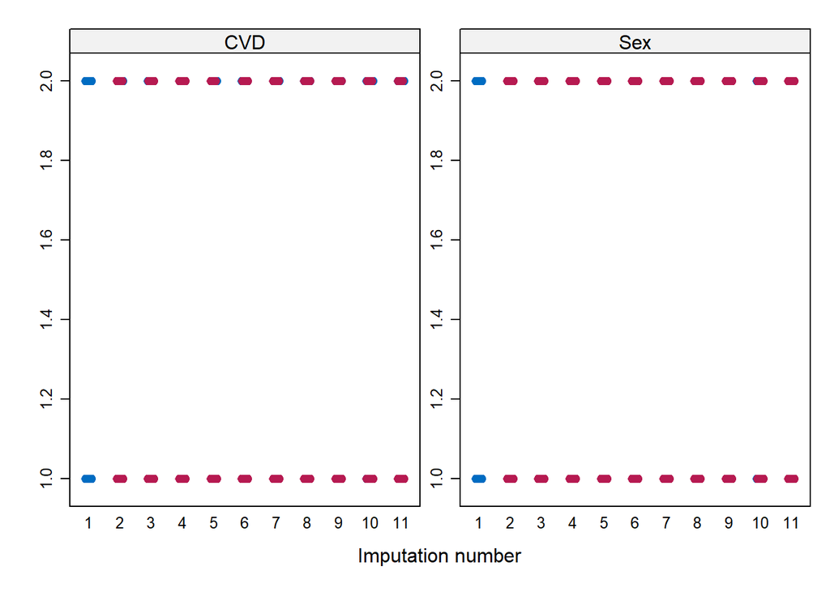

The graphs above show the dispersion of the imputed values. We see approximately reasonable dispersions indicating a stable imputation.

## 3.2 **outliers**

After “imputation” the missing data, we will start discovering the outliers:

```
##      Variable Num_Outliers Percent_Outliers
## 1       hsCRP         1397            13.19
## 2         PAL          170             1.60
## 3         Age            1             0.01
## 4         DBP           74             0.70
## 5 Cholesterol          172             1.62
## 6         BMI          143             1.35
## 7         HDL          189             1.78
```

### 3.2.1 **Step 1 — Extract outliers with ID for review**

Since there are many **outliers**, we can’t ignore them. We need to see which **ID** each outlier belongs to and check the other values for that person. This will show if all their data are unusual or if just this one value was entered wrong.

```
##    Variable Row_Number Value
## 1     hsCRP          4 25.31
## 2     hsCRP         13  8.42
## 3     hsCRP         16 40.70
## 4     hsCRP         17 24.07
## 5     hsCRP         19 20.25
## 6     hsCRP         23 11.30
## 7     hsCRP         24 49.30
## 8     hsCRP         29 20.97
## 9     hsCRP         31 10.55
## 10    hsCRP         32 11.65
```

### 3.2.2 **Step 2 — Define scientific/logical ranges**

We need to consider a normal range for each variable that includes a reasonable amount of even low or high values (for example, people with low or hight blood pressure ) to reduce dispersion as much as possible:

- **hsCRP:** 0 to 8 mg/L
- **PAL:** 1.2 to 2.5 (physical activity index)
- **Age:** 27 to 73 years (According to the dataset)
- **DBP:** 40 to 130 mmHg
- **Cholesterol:** 70 to 200 mg/dL
- **BMI:** 16 to 40 kg/m²
- **HDL:** 30 to 120 mg/dL

### 3.2.3 **Step 3 — Fix outliers**

we fix the outliers according to the specified ranges.

```
## [1] 0
```

```
## [1] 8
```

```
##      Variable Min_After_Winsor Max_After_Winsor
## 1       hsCRP              0.0              8.0
## 2         PAL              1.2              2.5
## 3         Age             27.0             73.0
## 4         DBP             40.0            130.0
## 5 Cholesterol             70.0            200.0
## 6         BMI             16.0             40.0
## 7         HDL             30.0             96.2
```

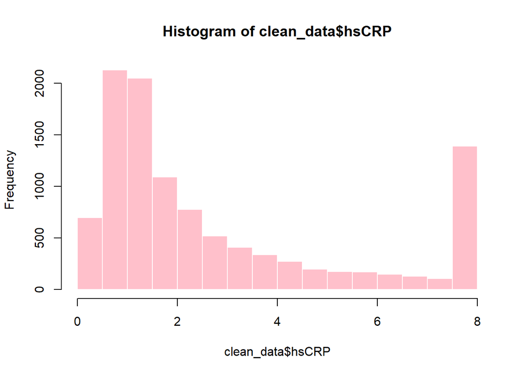

# 4 **Model Building (Linear Regression)**

We began by implementing a Linear Regression model to establish a baseline performance metric for predicting **hsCRP**.

```
## lm(formula = hsCRP ~ PAL + Age + DBP + Cholesterol + BMI + HDL +
##     CVD + Sex, data = clean_data)
```

```
##  coefficients table
```

coefficients table

| term | estimate | std.error | statistic | p.value |
| --- | --- | --- | --- | --- |
| (Intercept) | -4.3271 | 0.3510 | -12.3268 | 0.0000 |
| PAL | 0.6419 | 0.1128 | 5.6901 | 0.0000 |
| Age | 0.0153 | 0.0030 | 5.0277 | 0.0000 |
| DBP | -0.0002 | 0.0022 | -0.0701 | 0.9441 |
| Cholesterol | 0.0072 | 0.0011 | 6.7086 | 0.0000 |
| BMI | 0.1429 | 0.0062 | 23.0214 | 0.0000 |
| HDL | 0.0028 | 0.0027 | 1.0220 | 0.3068 |
| CVD1 | 0.3757 | 0.1635 | 2.2981 | 0.0216 |
| Sex1 | -0.0582 | 0.0617 | -0.9429 | 0.3458 |

```
##
##  Model Performance Metrics
```

Model Performance Metrics

| r.squared | adj.r.squared | sigma | statistic | p.value | df | logLik | AIC | BIC | deviance | df.residual | nobs |
| --- | --- | --- | --- | --- | --- | --- | --- | --- | --- | --- | --- |
| 0.0755 | 0.0748 | 2.4296 | 107.999 | 0 | 8 | -24434.5 | 48889.1 | 48961.7 | 62487.7 | 10586 | 10595 |

Variance Inflation Factors (VIF)

| Variable | VIF |
| --- | --- |
| PAL | 1.61814 |
| Age | 1.12796 |
| DBP | 1.14993 |
| Cholesterol | 1.15137 |
| BMI | 1.47487 |
| HDL | 1.21346 |
| CVD | 1.01882 |
| Sex | 1.63967 |

The low R-squared suggests that the model explains only a small fraction of the variability in hsCRP. However, the absence of multicollinearity among predictors indicates that the coefficients can still be interpreted with confidence

## 4.1 **Residual Diagnostics**

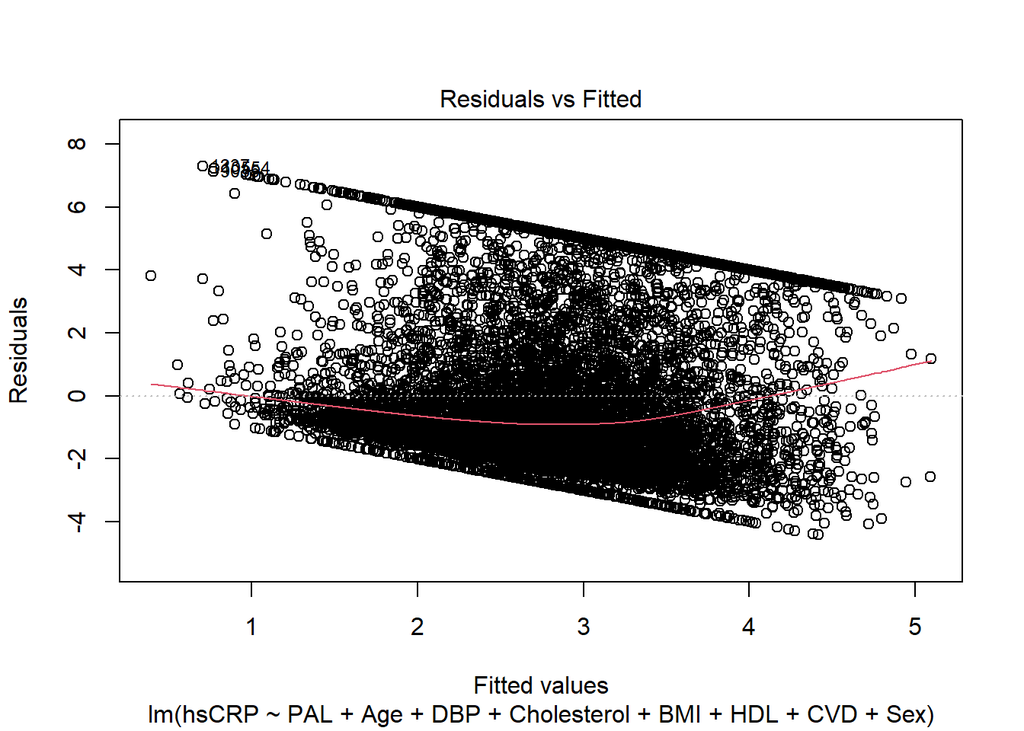

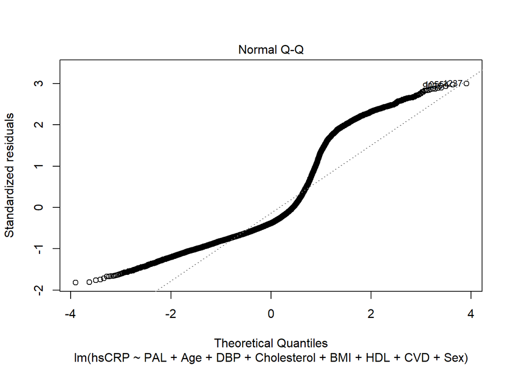

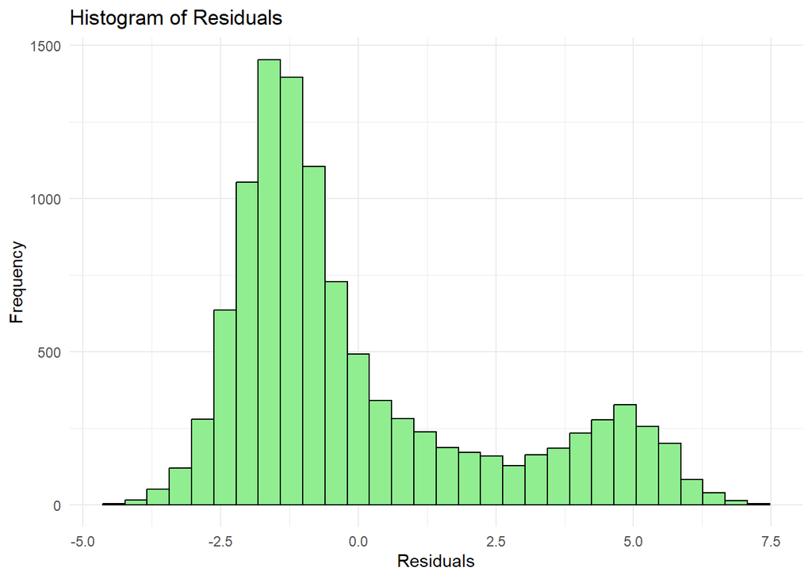

The residuals v.s fitted plot shows that the residuals are not randomly scattered around zero, indicating heteroscedasticity. A distinct linear cluster of points appears in the upper part of the plot, likely caused by a subgroup of observations (e.g., binary predictors such as CVD, Sex, or Diabetes) that the model does not capture well. This suggests that the linear regression assumptions are only partially satisfied, and further steps such as response transformation (e.g., log hsCRP , 1/hsCRP ) or considering model refinements may be needed to improve fit.

## 4.2 **Model Comparison (Linear Regression)**

Now we apply the desired transformations to the response variable to choose the best transformation:

```
##
## === Linear Model ===
```

```
## lm(formula = hsCRP ~ PAL + Age + DBP + Cholesterol + BMI + HDL +
##     CVD + Sex, data = clean_data)
```

```
##
## === Log-transformed Model ===
```

```
## lm(formula = log_hsCRP ~ PAL + Age + DBP + Cholesterol + BMI +
##     HDL + CVD + Sex, data = clean_data)
```

```
##
## === Inverse-transformed Model ===
```

```
## lm(formula = inv_hsCRP ~ PAL + Age + DBP + Cholesterol + BMI +
##     HDL + CVD + Sex, data = clean_data)
```

```
##
## === Robust Model ===
```

```
## rlm(formula = hsCRP ~ PAL + Age + DBP + Cholesterol + BMI + HDL +
##     CVD + Sex, data = clean_data)
```

```
##                 Model     R2_Type  R2_Value
## 1              Linear Adjusted R²  0.030980
## 2     Log-Transformed Adjusted R²  0.084384
## 3 Inverse-Transformed Adjusted R²  0.003352
## 4              Robust   Pseudo-R² -0.020905
```

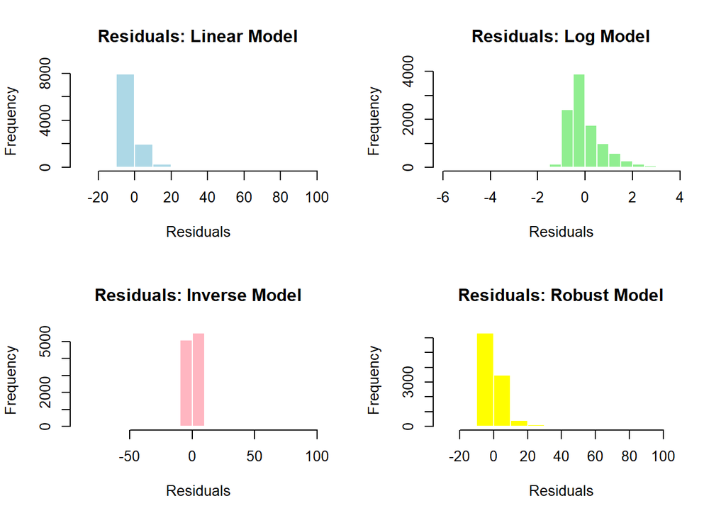

```
##                 Model Max_Cooks_D
## 1              Linear    0.058386
## 2     Log-Transformed    0.009471
## 3 Inverse-Transformed    0.390953
## 4              Robust          NA
```

```
## Number of influential points (Linear model): 350
```

```
## Number of influential points (Log model): 620
```

```
## Number of influential points (Inverse model): 30
```

```
## Number of influential points (Robust model): 4673
```

Next, we will apply the backward elimination method to identify the predictors that remain statistically significant and thus determine the final model:

```
##
## === Log-transformed Model ===
```

```
##  coefficients table  (Log-transformed Model)
```

coefficients table

| term | estimate | std.error | statistic | p.value |
| --- | --- | --- | --- | --- |
| (Intercept) | -0.9212 | 0.1024 | -8.9943 | 0.0000 |
| PAL | 0.2044 | 0.0334 | 6.1216 | 0.0000 |
| DBP | 0.0002 | 0.0007 | 0.2145 | 0.8301 |
| Age | 0.0037 | 0.0010 | 3.7853 | 0.0002 |
| Cholesterol | 0.0021 | 0.0002 | 10.1499 | 0.0000 |
| BMI | 0.0449 | 0.0019 | 23.2674 | 0.0000 |
| HDL | 0.0002 | 0.0008 | 0.2253 | 0.8217 |
| CVD1 | 0.1597 | 0.0521 | 3.0651 | 0.0022 |
| Sex1 | -0.0286 | 0.0196 | -1.4586 | 0.1447 |

```
##
##  Model Performance Metrics
```

Model Performance Metrics

| r.squared | adj.r.squared | sigma | statistic | p.value | df | logLik | AIC | BIC | deviance | df.residual | nobs |
| --- | --- | --- | --- | --- | --- | --- | --- | --- | --- | --- | --- |
| 0.0851 | 0.0844 | 0.7618 | 120.1 | 0 | 8 | -11853 | 23726 | 23798 | 5995 | 10330 | 10339 |

```
##
## === No-DBP Model ===
```

```
##  coefficients table  (No-DBP Model)
```

coefficients table

| term | estimate | std.error | statistic | p.value |
| --- | --- | --- | --- | --- |
| (Intercept) | -0.9138 | 0.0964 | -9.4794 | 0.0000 |
| PAL | 0.2042 | 0.0334 | 6.1182 | 0.0000 |
| Age | 0.0037 | 0.0009 | 3.9467 | 0.0001 |
| Cholesterol | 0.0021 | 0.0002 | 10.1809 | 0.0000 |
| BMI | 0.0449 | 0.0019 | 23.7311 | 0.0000 |
| HDL | 0.0002 | 0.0008 | 0.2301 | 0.8180 |
| CVD1 | 0.1599 | 0.0521 | 3.0697 | 0.0021 |
| Sex1 | -0.0290 | 0.0195 | -1.4837 | 0.1379 |

```
##
##  Model Performance Metrics
```

Model Performance Metrics

| r.squared | adj.r.squared | sigma | statistic | p.value | df | logLik | AIC | BIC | deviance | df.residual | nobs |
| --- | --- | --- | --- | --- | --- | --- | --- | --- | --- | --- | --- |
| 0.0851 | 0.0845 | 0.7618 | 137.3 | 0 | 7 | -11853 | 23724 | 23789 | 5995 | 10331 | 10339 |

```
##
## === No-HDL Model ===
```

```
##  coefficients table  (No-HDL Model)
```

coefficients table

| term | estimate | std.error | statistic | p.value |
| --- | --- | --- | --- | --- |
| (Intercept) | -0.9090 | 0.0941 | -9.656 | 0.0000 |
| PAL | 0.2052 | 0.0331 | 6.204 | 0.0000 |
| Age | 0.0037 | 0.0009 | 3.942 | 0.0001 |
| Cholesterol | 0.0021 | 0.0002 | 10.831 | 0.0000 |
| BMI | 0.0449 | 0.0019 | 23.831 | 0.0000 |
| CVD1 | 0.1594 | 0.0520 | 3.063 | 0.0022 |
| Sex1 | -0.0283 | 0.0193 | -1.466 | 0.1427 |

```
##
##  Model Performance Metrics
```

Model Performance Metrics

| r.squared | adj.r.squared | sigma | statistic | p.value | df | logLik | AIC | BIC | deviance | df.residual | nobs |
| --- | --- | --- | --- | --- | --- | --- | --- | --- | --- | --- | --- |
| 0.0851 | 0.0846 | 0.7617 | 160.1 | 0 | 6 | -11853 | 23722 | 23780 | 5995 | 10332 | 10339 |

# 5 **Model Building (Binary Logistic Regression)**

We preprocess hsCRP values by setting negatives to zero, capping extremes, and creating a binary variable using a **3 mg/L threshold**. A Binary Logistic Regression model then predicts high inflammation using age, sex, BMI, and other predictors, (The **reference group** includes individuals with **hsCRP ≤ 3 mg/L**, and the model estimates the likelihood of belonging to the hsCRP > 3 mg/L group.) (Hosmer et al., 2013)

```
##
## === Binary Logistic Regression Model ===
```

```
##
##  glm(hsCRP_binary ~ Age + Sex + BMI + Cholesterol
##                 + HDL + DBP + PAL + CVD,
##                data = clean_data, family = binomial
```

```
##
##  Model Performance Metrics (hsCRP > 3 mg/L)
```

| Metric | Value |
| --- | --- |
| AIC | 1.25e+04 |
| AUC | 6.53e-01 |
| Accuracy | 7.01e-01 |
| Misclassification Rate | 2.99e-01 |
| Sensitivity | 9.54e-01 |
| Specificity | 1.49e-01 |
| Precision | 7.09e-01 |
| F1-Score | 8.14e-01 |
| Hosmer-Lemeshow Chi-square | 1.09e+01 |
| Hosmer-Lemeshow p-value | 2.05e-01 |

```
##
##  Confusion Matrix
```

```
##           Reference
## Prediction    0    1
##          0 6925 2841
##          1  332  497
```

The overall accuracy of 70.05% is moderate but misleading on its own due to this severe imbalance in performance. The AUC of 0.6532 confirms that the model’s discriminative power is only fair.

## 5.1 **Model Comparison (Binary Logistic Regression)**

We are going to compare **Binary Logistic Regression** models based on model fit (AIC) and classification performance (Accuracy, Sensitivity, Specificity) to identify the best performing model.

```
## Coefficients Table with CI and OR (Full Binary Model)
```

Coefficients Table with Confidence Intervals and Odds Ratios

| Term | Coefficient | Std.Error | Coefficient_CI_95 | Odds_Ratio | OR_CI_95 | Statistic | P_value |
| --- | --- | --- | --- | --- | --- | --- | --- |
| (Intercept) | -6.0850 | 0.3044 | (-6.6834, -5.4902) | 0.0023 | (0.0013, 0.0041) | -19.9919 | 0.0000 |
| Age | 0.0104 | 0.0028 | (0.0049, 0.0159) | 1.0105 | (1.005, 1.016) | 3.7275 | 0.0002 |
| Sex1 | 0.0012 | 0.0568 | (-0.1101, 0.1127) | 1.0012 | (0.8957, 1.1193) | 0.0206 | 0.9836 |
| BMI | 0.1107 | 0.0057 | (0.0996, 0.1218) | 1.1170 | (1.1047, 1.1296) | 19.4827 | 0.0000 |
| Cholesterol | 0.0051 | 0.0006 | (0.0039, 0.0062) | 1.0051 | (1.0039, 1.0063) | 8.4522 | 0.0000 |
| HDL | -0.0030 | 0.0024 | (-0.0077, 0.0018) | 0.9970 | (0.9923, 1.0018) | -1.2238 | 0.2210 |
| DBP | -0.0006 | 0.0020 | (-0.0046, 0.0034) | 0.9994 | (0.9954, 1.0034) | -0.2926 | 0.7699 |
| PAL | 0.5398 | 0.0963 | (0.3508, 0.7282) | 1.7157 | (1.4202, 2.0715) | 5.6077 | 0.0000 |
| CVD1 | 0.3504 | 0.1420 | (0.07, 0.6271) | 1.4196 | (1.0725, 1.8722) | 2.4682 | 0.0136 |

```
##
## Model Performance Metrics
```

Model Performance Metrics

| Metric | Value |
| --- | --- |
| AUC | 0.65 |
| Accuracy | 0.70 |
| Sensitivity | 0.15 |
| Specificity | 0.95 |
| AIC | 12516.85 |

```
##
## Confusion Matrix (rows = Predictions, cols = Reference)
```

```
##           Reference
## Prediction    0    1
##          0 6925 2841
##          1  332  497
```

```
## Coefficients Table with CI and OR (no-sex model)
```

Coefficients Table with Confidence Intervals and Odds Ratios

| Term | Coefficient | Std.Error | Coefficient_CI_95 | Odds_Ratio | OR_CI_95 | Statistic | P_value |
| --- | --- | --- | --- | --- | --- | --- | --- |
| (Intercept) | -6.0872 | 0.2848 | (-6.6475, -5.5309) | 0.0023 | (0.0013, 0.004) | -21.371 | 0.0000 |
| Age | 0.0104 | 0.0028 | (0.005, 0.0159) | 1.0105 | (1.005, 1.016) | 3.744 | 0.0002 |
| BMI | 0.1107 | 0.0051 | (0.1008, 0.1207) | 1.1171 | (1.1061, 1.1283) | 21.868 | 0.0000 |
| Cholesterol | 0.0051 | 0.0006 | (0.0039, 0.0062) | 1.0051 | (1.0039, 1.0063) | 8.455 | 0.0000 |
| HDL | -0.0030 | 0.0024 | (-0.0077, 0.0017) | 0.9970 | (0.9924, 1.0017) | -1.235 | 0.2168 |
| DBP | -0.0006 | 0.0020 | (-0.0046, 0.0034) | 0.9994 | (0.9954, 1.0034) | -0.295 | 0.7676 |
| PAL | 0.5409 | 0.0827 | (0.3788, 0.703) | 1.7175 | (1.4606, 2.0198) | 6.541 | 0.0000 |
| CVD1 | 0.3503 | 0.1419 | (0.07, 0.6269) | 1.4195 | (1.0725, 1.8719) | 2.469 | 0.0136 |

```
##
## Model Performance Metrics
```

Model Performance Metrics

| Metric | Value |
| --- | --- |
| AUC | 0.65 |
| Accuracy | 0.70 |
| Sensitivity | 0.15 |
| Specificity | 0.95 |
| AIC | 12514.85 |

```
##
## Confusion Matrix (rows = Predictions, cols = Reference)
```

```
##           Reference
## Prediction    0    1
##          0 6925 2840
##          1  332  498
```

```
## Coefficients Table with CI and OR (no-DBP model)
```

Coefficients Table with Confidence Intervals and Odds Ratios

| Term | Coefficient | Std.Error | Coefficient_CI_95 | Odds_Ratio | OR_CI_95 | Statistic | P_value |
| --- | --- | --- | --- | --- | --- | --- | --- |
| (Intercept) | -6.1193 | 0.2634 | (-6.6377, -5.6051) | 0.0022 | (0.0013, 0.0037) | -23.23 | 0.0000 |
| Age | 0.0102 | 0.0027 | (0.0049, 0.0155) | 1.0103 | (1.0049, 1.0156) | 3.79 | 0.0001 |
| BMI | 0.1105 | 0.0050 | (0.1007, 0.1203) | 1.1168 | (1.106, 1.1279) | 22.10 | 0.0000 |
| Cholesterol | 0.0051 | 0.0006 | (0.0039, 0.0062) | 1.0051 | (1.0039, 1.0062) | 8.45 | 0.0000 |
| HDL | -0.0030 | 0.0024 | (-0.0077, 0.0017) | 0.9970 | (0.9924, 1.0017) | -1.24 | 0.2164 |
| PAL | 0.5429 | 0.0824 | (0.3814, 0.7045) | 1.7209 | (1.4643, 2.0228) | 6.59 | 0.0000 |
| CVD1 | 0.3493 | 0.1419 | (0.0691, 0.6259) | 1.4181 | (1.0715, 1.87) | 2.46 | 0.0138 |

```
##
## Model Performance Metrics
```

Model Performance Metrics

| Metric | Value |
| --- | --- |
| AUC | 0.65 |
| Accuracy | 0.70 |
| Sensitivity | 0.15 |
| Specificity | 0.95 |
| AIC | 12512.94 |

```
##
## Confusion Matrix (rows = Predictions, cols = Reference)
```

```
##           Reference
## Prediction    0    1
##          0 6925 2841
##          1  332  497
```

```
## Coefficients Table with CI and OR (no-HDL model)
```

Coefficients Table with Confidence Intervals and Odds Ratios

| Term | Coefficient | Std.Error | Coefficient_CI_95 | Odds_Ratio | OR_CI_95 | Statistic | P_value |
| --- | --- | --- | --- | --- | --- | --- | --- |
| (Intercept) | -6.1688 | 0.2604 | (-6.6814, -5.6605) | 0.0021 | (0.0013, 0.0035) | -23.69 | 0.0000 |
| Age | 0.0104 | 0.0027 | (0.0051, 0.0157) | 1.0104 | (1.0051, 1.0158) | 3.86 | 0.0001 |
| BMI | 0.1105 | 0.0050 | (0.1008, 0.1204) | 1.1169 | (1.106, 1.1279) | 22.13 | 0.0000 |
| Cholesterol | 0.0048 | 0.0006 | (0.0037, 0.0059) | 1.0048 | (1.0037, 1.0059) | 8.52 | 0.0000 |
| PAL | 0.5170 | 0.0797 | (0.3608, 0.6734) | 1.6770 | (1.4345, 1.961) | 6.48 | 0.0000 |
| CVD1 | 0.3565 | 0.1418 | (0.0764, 0.633) | 1.4284 | (1.0794, 1.8832) | 2.51 | 0.0119 |

```
##
## Model Performance Metrics
```

Model Performance Metrics

| Metric | Value |
| --- | --- |
| AUC | 0.65 |
| Accuracy | 0.70 |
| Sensitivity | 0.15 |
| Specificity | 0.95 |
| AIC | 12512.47 |

```
##
## Confusion Matrix (rows = Predictions, cols = Reference)
```

```
##           Reference
## Prediction    0    1
##          0 6927 2842
##          1  330  496
```

The **final model** shows how different factors affect the likelihood of **having high inflammation** (hsCRP > 3 mg/L). Here’s what the **odds ratios (OR)** tell us:

**Coefficients Interpretation**

**Age:** Each year of age increases the risk of high inflammation by about 1% (OR = 1.010)

**BMI:** Each unit increase in BMI increases the risk by about 12% (OR = 1.117)

**Cholesterol:** Each unit increase in cholesterol increases the risk by about 0.5% (OR = 1.005)

**Physical Activity (PAL):** Higher activity levels increase the risk by about 68% (OR = 1.677)

**Heart Disease (CVD):** Having heart disease increases the risk by about 43% (OR = 1.428)

**Note:** The physical activity result is surprising since we usually expect more activity to reduce inflammation. This might need further investigation.

**Model Performance Metrics**

**Accuracy:** The model is correct 70% of the time

**Specificity:** Very good at identifying people with **low inflammation** (95% correct)

**Overall Performance:** This model would be useful for identifying people with low inflammation levels, but it would miss most people who actually have high inflammation. If you’re using this for health screening, you might want to adjust the model or use additional tests to catch more high-risk cases.

# 6 **Model Building (Standard Ordinal Logistic Regression)**

We are going to fit a **Standard Ordinal Logistic** (proportional-odds) model because the **outcome has ordered categories (“Low (<1)”, “Medium (1-3)”, “High (>3)”)** instead of just yes/no. The model estimates how each predictor affects the log-odds of being in a **higher outcome category**, holding other variables constant (Hosmer et al., 2013). Key assumptions to check are the proportional-odds (parallel lines) assumption and reasonable model fit. We will also run a test for the **parallel lines assumption** before finalizing interpretation.

Coefficients Table with OR and CI (Ordinal Logistic Regression)

|  | Value | Std. Error | t value | p.value | OR | CI 2.5% | CI 97.5% |
| --- | --- | --- | --- | --- | --- | --- | --- |
| PAL | 0.436 | 0.082 | 5.318 | 0.000 | 1.547 | 1.317 | 1.82 |
| Age | 0.011 | 0.002 | 4.791 | 0.000 | 1.011 | 1.007 | 1.02 |
| DBP | 0.001 | 0.002 | 0.566 | 0.571 | 1.001 | 0.998 | 1.00 |
| Cholesterol | 0.005 | 0.001 | 10.560 | 0.000 | 1.006 | 1.004 | 1.01 |
| BMI | 0.114 | 0.005 | 23.297 | 0.000 | 1.121 | 1.110 | 1.13 |
| HDL | 0.000 | 0.002 | 0.230 | 0.818 | 1.000 | 0.997 | 1.00 |
| CVD1 | 0.162 | 0.130 | 1.249 | 0.212 | 1.176 | 0.912 | 1.52 |
| Sex1 | -0.012 | 0.048 | -0.255 | 0.799 | 0.988 | 0.899 | 1.08 |
| Low\|Medium | 4.476 | 0.256 | 17.472 | 0.000 | 87.861 | 1.317 | 1.82 |
| Medium\|High | 6.405 | 0.260 | 24.600 | 0.000 | 605.042 | 1.007 | 1.02 |

```
## fitting null model for pseudo-r2
```

Model Performance Metrics

| Metric | Value |
| --- | --- |
| Multiclass AUC | 6.03e-01 |
| Accuracy | 4.50e-01 |
| Pseudo R² (McFadden) | 4.50e-02 |
| -2*Log-Likelihood | 2.19e+04 |
| AIC | 2.19e+04 |

```
##
##  Test of Parallel Lines
```

```
##
## Tests for Proportional Odds
## polr(formula = hsCRP_ord ~ PAL + Age + DBP + Cholesterol + BMI +
##     HDL + CVD + Sex, data = clean_data, Hess = TRUE)
##
##               b[polr]   b[>Low] b[>Medium] Chisquare df Pr(>Chisq)
## Overall                                        29.55  8    0.00025 ***
## PAL          0.436373  0.325526   0.539835      3.83  1    0.05036 .
## Age          0.011315  0.012683   0.010424      0.49  1    0.48368
## DBP          0.000984  0.002520  -0.000598      1.71  1    0.19041
## Cholesterol  0.005458  0.006065   0.005061      1.96  1    0.16112
## BMI          0.114095  0.117929   0.110662      1.13  1    0.28870
## HDL          0.000468  0.003139  -0.002968      4.73  1    0.02966 *
## CVD1         0.162481 -0.087411   0.350388      7.68  1    0.00559 **
## Sex1        -0.012176 -0.023219   0.001171      0.14  1    0.70556
## ---
## Signif. codes:  0 '***' 0.001 '**' 0.01 '*' 0.05 '.' 0.1 ' ' 1
```

Likelihood Ratio Test: Null vs Full Model

| Model_Comparison | Chi_Square | df | p_value |
| --- | --- | --- | --- |
| Null vs Full Model | 1028 | 8 | 0 |

```
##
##  Confusion Matrix
```

Confusion Matrix

| Actual | Low | Medium | High |
| --- | --- | --- | --- |
| Low | 500 | 404 | 164 |
| Medium | 2094 | 3235 | 2139 |
| High | 230 | 794 | 1035 |

The **ordinal logistic regression** model was fitted to predict ordered **hsCRP** categories. Model performance was modest: multiclass AUC = 0.603, overall accuracy = 0.45, and McFadden’s pseudo-R² = 0.045, indicating limited explanatory power. The likelihood-ratio test comparing the null and full model was highly significant (χ² = 1028, df = 8, p < 0.001), showing the predictors jointly improve model fit.

However, **the proportional-odds (parallel-lines) assumption was rejected** (Brant overall χ² = 29.55, df = 8, p = 0.00025). Item-level tests identified CVD (p = 0.0056) and HDL (p = 0.0297) as significantly non-proportional; PAL was borderline (p ≈ 0.050). This implies that the effect of these predictors differs across the Low→Medium and Medium→High thresholds, so the standard proportional-odds model is not strictly appropriate. The confusion matrix indicated the model tends to predict the middle category more often; class-specific performance (e.g., sensitivity for High) was limited and should be examined when selecting the final approach.

Given this violation, the next step is to apply a **Generalized Ordinal Logistic Regression model**, which relaxes the parallel-lines assumption and allows coefficients to vary across cut-points. This approach provides a more flexible framework for handling predictors with non-proportional effects.

# 7 **Model Building (Generalized Ordinal Logistic Regression)**

We fit a **generalized ordinal logistic model** that **fully relaxes** the parallel-lines assumption (a fully non-parallel specification). In this specification each predictor receives **separate coefficients at each adjacent threshold**, so effects may differ between the Low→Medium and Medium→High transitions. Practically, we will:

1. Fit the full non-parallel model (all predictors free across thresholds).
2. Compare its fit to the standard proportional-odds model using AIC and likelihood-ratio tests to justify the added flexibility.
3. Report threshold-specific odds ratios (ORs) with 95% CIs and classification diagnostics (multiclass AUC, accuracy, confusion matrix).

Interpretation will focus on predictors that show substantively different effects across thresholds (for example, CVD or HDL), and on whether the non-parallel model materially improves fit and predictive performance.

Generalized Ordinal Logistic Regression Coefficients

|  | Variable | Comparison | Coefficient | Std_Error | Odds_Ratio | CI_2.5 | CI_97.5 | p_value |
| --- | --- | --- | --- | --- | --- | --- | --- | --- |
| (Intercept):1 | (Intercept) | Low vs Medium | 4.916 | 0.320 | 136.507 | 72.973 | 255.357 | 0.000 |
| (Intercept):2 |  | Low+Medium vs High | 6.065 | 0.303 | 430.432 | 237.817 | 779.050 | 0.000 |
| PAL:1 | PAL | Low vs Medium | -0.326 | 0.100 | 0.722 | 0.593 | 0.879 | 0.001 |
| PAL:2 |  | Low+Medium vs High | -0.532 | 0.096 | 0.587 | 0.487 | 0.709 | 0.000 |
| Age:1 | Age | Low vs Medium | -0.012 | 0.003 | 0.988 | 0.982 | 0.993 | 0.000 |
| Age:2 |  | Low+Medium vs High | -0.010 | 0.003 | 0.990 | 0.984 | 0.995 | 0.000 |
| DBP:1 | DBP | Low vs Medium | -0.003 | 0.002 | 0.997 | 0.993 | 1.002 | 0.234 |
| DBP:2 |  | Low+Medium vs High | 0.000 | 0.002 | 1.000 | 0.997 | 1.004 | 0.821 |
| Cholesterol:1 | Cholesterol | Low vs Medium | -0.006 | 0.001 | 0.994 | 0.993 | 0.995 | 0.000 |
| Cholesterol:2 |  | Low+Medium vs High | -0.005 | 0.001 | 0.995 | 0.994 | 0.996 | 0.000 |
| BMI:1 | BMI | Low vs Medium | -0.121 | 0.006 | 0.886 | 0.875 | 0.897 | 0.000 |
| BMI:2 |  | Low+Medium vs High | -0.110 | 0.006 | 0.896 | 0.886 | 0.906 | 0.000 |
| HDL:1 | HDL | Low vs Medium | -0.004 | 0.002 | 0.996 | 0.991 | 1.001 | 0.090 |
| HDL:2 |  | Low+Medium vs High | 0.002 | 0.002 | 1.002 | 0.998 | 1.007 | 0.299 |
| CVD1:1 | CVD1 | Low vs Medium | 0.088 | 0.158 | 1.092 | 0.801 | 1.489 | 0.578 |
| CVD1:2 |  | Low+Medium vs High | -0.328 | 0.142 | 0.720 | 0.546 | 0.951 | 0.021 |
| Sex1:1 | Sex1 | Low vs Medium | 0.015 | 0.059 | 1.015 | 0.905 | 1.138 | 0.801 |
| Sex1:2 |  | Low+Medium vs High | 0.006 | 0.057 | 1.006 | 0.901 | 1.125 | 0.909 |

Model Performance Metrics

| Metric | Value |
| --- | --- |
| Accuracy | 4.56e-01 |
| Pseudo R-squared | 4.60e-02 |
| AIC | 2.19e+04 |
| AUC | 6.06e-01 |
| Sensitivity (Low) | 2.26e-01 |
| Sensitivity (Medium) | 7.28e-01 |
| Sensitivity (High) | 2.89e-01 |
| Specificity (Low) | 9.04e-01 |
| Specificity (Medium) | 3.31e-01 |
| Specificity (High) | 8.76e-01 |

Confusion Matrix

| Actual | Low | Medium | High |
| --- | --- | --- | --- |
| Low | 639 | 508 | 239 |
| Medium | 1988 | 3225 | 2134 |
| High | 197 | 700 | 965 |

Likelihood Ratio Test Results

| Test | Chi_Square | df | p_value |
| --- | --- | --- | --- |
| Likelihood Ratio Test | 1060 | 16 | 0 |

```
## --------------------------------------------
## Test for X2  df  probability
## --------------------------------------------
## Omnibus      29.55   8   0
## PAL      3.83    1   0.05
## Age      0.49    1   0.48
## DBP      1.71    1   0.19
## Cholesterol  1.96    1   0.16
## BMI      1.13    1   0.29
## HDL      4.73    1   0.03
## CVD1     7.68    1   0.01
## Sex1     0.14    1   0.71
## --------------------------------------------
##
## H0: Parallel Regression Assumption holds
```

Brant Test for Proportional Odds

[output not shown]

Correct Classification Matrix

|  | Class | Correctly_Classified | Total_Observations | Percentage_Correct |
| --- | --- | --- | --- | --- |
| Low | Low | 639 | 2824 | 22.6 |
| Medium | Medium | 3225 | 4433 | 72.8 |
| High | High | 965 | 3338 | 28.9 |

**Summary:** The non-parallel ordinal model fits significantly better than the null model (Likelihood-Ratio test), but explanatory power is limited (McFadden pseudo-R² ≈ 0.046) and overall accuracy is moderate (~0.46). The proportional-odds test indicates some predictors (notably CVD and HDL) have non-constant effects across thresholds, so threshold-specific coefficients are reported. The model predicts the Medium category best; classification for Low and High is weaker. In the next section we will compare models more formally (AIC, multiclass AUC, and classification metrics) to select the final approach.

## 7.1 **Model Comparison (Generalized Ordinal Logistic Regression)**

In this stage, generalized ordinal logistic regression models are compared in order to identify the best-fitting and most parsimonious model. The evaluation focuses on both statistical model fit criteria (such as AIC and pseudo R²) and predictive performance measures (such as accuracy, multiclass AUC, and class-specific sensitivity/specificity).

This process helps in selecting the most reliable model that captures the relationship between predictors and the ordinal outcome while avoiding overfitting.

```
##
##  Full Model
```

Generalized Ordinal Logistic Regression Coefficients - Full Model

|  | Variable | Comparison | Coefficient | Std_Error | Odds_Ratio | CI_2.5 | CI_97.5 | p_value |
| --- | --- | --- | --- | --- | --- | --- | --- | --- |
| (Intercept):1 | (Intercept) | Low vs Medium | 4.916 | 0.320 | 136.507 | 72.973 | 255.357 | 0.000 |
| (Intercept):2 |  | Low+Medium vs High | 6.065 | 0.303 | 430.432 | 237.817 | 779.050 | 0.000 |
| PAL:1 | PAL | Low vs Medium | -0.326 | 0.100 | 0.722 | 0.593 | 0.879 | 0.001 |
| PAL:2 |  | Low+Medium vs High | -0.532 | 0.096 | 0.587 | 0.487 | 0.709 | 0.000 |
| Age:1 | Age | Low vs Medium | -0.012 | 0.003 | 0.988 | 0.982 | 0.993 | 0.000 |
| Age:2 |  | Low+Medium vs High | -0.010 | 0.003 | 0.990 | 0.984 | 0.995 | 0.000 |
| DBP:1 | DBP | Low vs Medium | -0.003 | 0.002 | 0.997 | 0.993 | 1.002 | 0.234 |
| DBP:2 |  | Low+Medium vs High | 0.000 | 0.002 | 1.000 | 0.997 | 1.004 | 0.821 |
| Cholesterol:1 | Cholesterol | Low vs Medium | -0.006 | 0.001 | 0.994 | 0.993 | 0.995 | 0.000 |
| Cholesterol:2 |  | Low+Medium vs High | -0.005 | 0.001 | 0.995 | 0.994 | 0.996 | 0.000 |
| BMI:1 | BMI | Low vs Medium | -0.121 | 0.006 | 0.886 | 0.875 | 0.897 | 0.000 |
| BMI:2 |  | Low+Medium vs High | -0.110 | 0.006 | 0.896 | 0.886 | 0.906 | 0.000 |
| HDL:1 | HDL | Low vs Medium | -0.004 | 0.002 | 0.996 | 0.991 | 1.001 | 0.090 |
| HDL:2 |  | Low+Medium vs High | 0.002 | 0.002 | 1.002 | 0.998 | 1.007 | 0.299 |
| CVD1:1 | CVD1 | Low vs Medium | 0.088 | 0.158 | 1.092 | 0.801 | 1.489 | 0.578 |
| CVD1:2 |  | Low+Medium vs High | -0.328 | 0.142 | 0.720 | 0.546 | 0.951 | 0.021 |
| Sex1:1 | Sex1 | Low vs Medium | 0.015 | 0.059 | 1.015 | 0.905 | 1.138 | 0.801 |
| Sex1:2 |  | Low+Medium vs High | 0.006 | 0.057 | 1.006 | 0.901 | 1.125 | 0.909 |

```
##
## === FULL MODEL RESULTS ===
```

```
## AIC: 21879
```

```
## Pseudo R-squared (McFadden): 0.0463
```

Likelihood Ratio Test: Null vs Full Model

| Test | Chi_Square | df | p_value |
| --- | --- | --- | --- |
| Likelihood Ratio Test (Full vs Null) | 1060 | 16 | 0 |

```
##
##  No-Sex Model
```

Generalized Ordinal Logistic Regression Coefficients - No-Sex Model

|  | Variable | Comparison | Coefficient | Std_Error | Odds_Ratio | CI_2.5 | CI_97.5 | p_value |
| --- | --- | --- | --- | --- | --- | --- | --- | --- |
| (Intercept):1 | (Intercept) | Medium vs Low | 4.887 | 0.298 | 132.604 | 73.990 | 237.651 | 0.000 |
| (Intercept):2 |  | Low+Medium vs High | 6.052 | 0.283 | 425.037 | 243.973 | 740.476 | 0.000 |
| PAL:1 | PAL | Medium vs Low | -0.312 | 0.085 | 0.732 | 0.619 | 0.865 | 0.000 |
| PAL:2 |  | Low+Medium vs High | -0.526 | 0.082 | 0.591 | 0.503 | 0.694 | 0.000 |
| Age:1 | Age | Medium vs Low | -0.013 | 0.003 | 0.988 | 0.982 | 0.993 | 0.000 |
| Age:2 |  | Low+Medium vs High | -0.011 | 0.003 | 0.990 | 0.984 | 0.995 | 0.000 |
| DBP:1 | DBP | Medium vs Low | -0.003 | 0.002 | 0.997 | 0.993 | 1.002 | 0.222 |
| DBP:2 |  | Low+Medium vs High | 0.000 | 0.002 | 1.000 | 0.997 | 1.004 | 0.828 |
| Cholesterol:1 | Cholesterol | Medium vs Low | -0.006 | 0.001 | 0.994 | 0.993 | 0.995 | 0.000 |
| Cholesterol:2 |  | Low+Medium vs High | -0.005 | 0.001 | 0.995 | 0.994 | 0.996 | 0.000 |
| BMI:1 | BMI | Medium vs Low | -0.120 | 0.006 | 0.887 | 0.877 | 0.897 | 0.000 |
| BMI:2 |  | Low+Medium vs High | -0.110 | 0.005 | 0.896 | 0.887 | 0.905 | 0.000 |
| HDL:1 | HDL | Medium vs Low | -0.004 | 0.002 | 0.996 | 0.991 | 1.001 | 0.094 |
| HDL:2 |  | Low+Medium vs High | 0.002 | 0.002 | 1.003 | 0.998 | 1.007 | 0.285 |
| CVD1:1 | CVD1 | Medium vs Low | 0.087 | 0.158 | 1.091 | 0.800 | 1.487 | 0.582 |
| CVD1:2 |  | Low+Medium vs High | -0.328 | 0.142 | 0.720 | 0.545 | 0.950 | 0.020 |

```
##
## === NO-SEX MODEL RESULTS ===
```

```
## AIC: 21876
```

```
## Pseudo R-squared (McFadden): 0.0463
```

Likelihood Ratio Test: Null vs No-Sex Model

| Test | Chi_Square | df | p_value |
| --- | --- | --- | --- |
| Likelihood Ratio Test (No-Sex vs Null) | 1060 | 14 | 0 |

```
##
##  No-DBP Model
```

Generalized Ordinal Logistic Regression Coefficients - No-DBP Model

|  | Variable | Comparison | Coefficient | Std_Error | Odds_Ratio | CI_2.5 | CI_97.5 | p_value |
| --- | --- | --- | --- | --- | --- | --- | --- | --- |
| (Intercept):1 | (Intercept) | Low vs Medium | 4.744 | 0.274 | 114.902 | 67.146 | 196.624 | 0.000 |
| (Intercept):2 |  | Low+Medium vs High | 6.077 | 0.262 | 435.568 | 260.765 | 727.549 | 0.000 |
| PAL:1 | PAL | Low vs Medium | -0.303 | 0.085 | 0.739 | 0.625 | 0.873 | 0.000 |
| PAL:2 |  | Low+Medium vs High | -0.528 | 0.082 | 0.590 | 0.502 | 0.693 | 0.000 |
| Age:1 | Age | Low vs Medium | -0.013 | 0.003 | 0.987 | 0.981 | 0.992 | 0.000 |
| Age:2 |  | Low+Medium vs High | -0.010 | 0.003 | 0.990 | 0.985 | 0.995 | 0.000 |
| Cholesterol:1 | Cholesterol | Low vs Medium | -0.006 | 0.001 | 0.994 | 0.993 | 0.995 | 0.000 |
| Cholesterol:2 |  | Low+Medium vs High | -0.005 | 0.001 | 0.995 | 0.994 | 0.996 | 0.000 |
| BMI:1 | BMI | Low vs Medium | -0.121 | 0.006 | 0.886 | 0.876 | 0.896 | 0.000 |
| BMI:2 |  | Low+Medium vs High | -0.110 | 0.005 | 0.896 | 0.888 | 0.905 | 0.000 |
| HDL:1 | HDL | Low vs Medium | -0.004 | 0.002 | 0.996 | 0.991 | 1.001 | 0.096 |
| HDL:2 |  | Low+Medium vs High | 0.002 | 0.002 | 1.002 | 0.998 | 1.007 | 0.287 |
| CVD1:1 | CVD1 | Low vs Medium | 0.084 | 0.158 | 1.088 | 0.798 | 1.483 | 0.593 |
| CVD1:2 |  | Low+Medium vs High | -0.328 | 0.142 | 0.721 | 0.546 | 0.951 | 0.021 |

```
##
## === NO-DBP MODEL RESULTS ===
```

```
## AIC: 21874
```

```
## Pseudo R-squared (McFadden): 0.0462
```

Likelihood Ratio Test: Null vs No-DBP Model

| Test | Chi_Square | df | p_value |
| --- | --- | --- | --- |
| Likelihood Ratio Test (No-DBP vs Null) | 1058 | 12 | 0 |

```
##
## === MODEL COMPARISON TABLE ===
```

Model Comparison based on AIC, AUC and Classification Performance

|  | Model | AIC | AUC | Accuracy | Pseudo_R2 | Low_Class_Percent | Medium_Class_Percent | High_Class_Percent | Avg_Class_Percent |
| --- | --- | --- | --- | --- | --- | --- | --- | --- | --- |
| Accuracy | Full Model | 21879 | 0.606 | 0.456 | 0.046 | 22.6 | 72.8 | 28.9 | 41.4 |
| Accuracy1 | No-Sex Model | 21876 | 0.607 | 0.456 | 0.046 | 22.7 | 72.7 | 29.0 | 41.4 |
| Accuracy2 | No-DBP Model | 21874 | 0.607 | 0.455 | 0.046 | 22.7 | 72.5 | 28.8 | 41.4 |

```
##
## === DETAILED CORRECT CLASSIFICATION MATRICES ===
```

Detailed Correct Classification Matrices for All Models

|  | Model | Class | Correctly_Classified | Total_Observations | Percentage_Correct |
| --- | --- | --- | --- | --- | --- |
| Low | Full Model | Low | 639 | 2824 | 22.6 |
| Medium | Full Model | Medium | 3225 | 4433 | 72.8 |
| High | Full Model | High | 965 | 3338 | 28.9 |
| Low1 | No-Sex Model | Low | 641 | 2824 | 22.7 |
| Medium1 | No-Sex Model | Medium | 3221 | 4433 | 72.7 |
| High1 | No-Sex Model | High | 967 | 3338 | 29.0 |
| Low2 | No-DBP Model | Low | 641 | 2824 | 22.7 |
| Medium2 | No-DBP Model | Medium | 3215 | 4433 | 72.5 |
| High2 | No-DBP Model | High | 962 | 3338 | 28.8 |

**Interpretation**

**Significant Variables at Both Thresholds:**

**Age:**

- Low vs. Medium: OR = 0.987 (95% CI: 0.981-0.992)
- Combined vs. High: OR = 0.990 (95% CI: 0.985-0.995)
- Interpretation: Each additional year of age slightly decreases the probability of belonging to lower hsCRP categories.

**Cholesterol:**

- Low vs. Medium: OR = 0.994 (95% CI: 0.993-0.995)
- Combined vs. High: OR = 0.995 (95% CI: 0.994-0.996)
- Interpretation: Higher cholesterol levels are associated with increased probability of higher hsCRP categories.

**BMI:**

- Low vs. Medium: OR = 0.886 (95% CI: 0.876-0.896)
- Combined vs. High: OR = 0.896 (95% CI: 0.888-0.905)
- Interpretation: Higher BMI significantly increases the probability of elevated hsCRP levels at both thresholds.

**Partially Significant Variables:**

**Model Performance Metrics**

**AIC (21874):**

- (slightly lower than alternatives: Full = 21879, No-Sex = 21876) — lower AIC favors this specification.

**Pseudo R² (0.0462):**

- modest explanatory power.(Typical for biological and medical models where numerous unmeasured factors influence outcomes).

**Likelihood-ratio test (No-DBP vs null):**

- predictors collectively improve fit.(χ² = 1058, df = 12, p < 0.001)

**Accuracy (0.455):**

- Moderate overall classification accuracy (45.5%)
- Indicates limitations in precise hsCRP category prediction

**AUC (0.607):**

- Fair discriminative ability (0.6-0.7 range)
- Moderate predictive power for clinical application

**Classification Matrix Analysis**

**Low Category:**

- Only 22.7% correctly classified
- Poor performance in identifying low hsCRP cases

**Medium Category:**

- 72.5% correctly classified
- Best performance across all categories

**High Category:**

28.8% correctly classified

Limited ability to identify high-risk cases

**Clinical and Research Implications**

- This model helps us understand what factors affect hsCRP levels, but it’s not perfect for predicting individual cases and shows real relationships between factors like physical activity, age, and cholesterol with hsCRP levels. **It works better for identifying medium risk cases than low or high risk cases**.
- Even though HDL and CVD weren’t strongly significant in all tests, keeping them in the model improves its overall quality. The model suggests that other factors we didn’t measure probably also affect hsCRP levels.
- Doctors can use this information to understand which patients might have higher inflammation risks
- Researchers should look for additional factors that could improve prediction of low and high hsCRP cases
- The model confirms that lifestyle factors (activity, cholesterol, BMI) are important for inflammation management
- This model gives us useful information about hsCRP, but we need more research to make better predictions, especially for the highest and lowest risk groups.